# Спецификация к Лабораторной работе №11

# Процедуры и функции.

# Поиск экстремума среди трех значений

# (Вариант 22)

## Абстракция А0

### 1. Постановка задачи.

#### Задание:

Написать две программы обработки трех двумерных массивов.

В первой версии программы использовать только процедуры общего вида.

Во второй версии программы должна быть хотя бы одна функция.

#### Условие:

Найти сумму элементов для каждой из трех матриц.

Для каждой из матриц сформировать одномерный массив,

равный по длине количеству строк матрицы и содержащий значения 0 или 1:

- 1, если в соответствующей строке элемент на главной диагонали больше других элементов этой строки;
- 0, если это условие для данной строки не выполняется.

Определить матрицу с максимальной суммой элементов.

### 2. Уточненная постановка задачи.

Даны матрицы $A, B, C$ с размерностями $n_A \times n_A, \ n_B \times n_B, \ n_C \times n_C$ .

Получить три массива $\{X_1, X_2, ..., X_{n_A}\}, \{X_1, X_2, ..., X_{n_B}\}, \{X_1, X_2, ..., X_{n_C}\}$ по правилу:

$\large{\displaystyle{X_i = \begin{cases} 1, \ Y_{ii} > Y_{ij}, \ \forall j: 0<j<n_Y+1 \land j \neq i\\ 0, \ Y_{ii} \leq Y_{ij}, \ \exists j: 0<j<n_Y+1 \land j \neq i\\ \end{cases}, \ \forall i: 0<i<n_Y+1, \ \forall Y \in \{A, B, C\} \ (*)}}$.

Найти $\large{\displaystyle{S_Y = \sum_{\substack{0<i<n_Y+1 \\ 0<j<n_Y+1}} Y_{ij}, \ \forall Y \in \{A, B, C\} }}$.

Определить $\large{\displaystyle{\max_{Y \in \{A, B, C\}} S_Y }}$.

### 3. Пример с иллюстрацией.

```python
from IPython.display import Image
import numpy
import pylab
%matplotlib inline
pylab.style.use('seaborn-whitegrid')
```

```python
def write_datatxt(file_name, A, B, C):
    with open(file_name, 'w') as f:
        for Y in [A, B, C]:
            f.write("{}\n".format(Y.shape[0]))
            for i in range(Y.shape[0]):
                f.write("{}\n".format(Y[i]))
```

```python
A1 = numpy.random.randint(-100, 100, size=(5,5))
B1 = numpy.random.randint(-100, 100, size=(4,4))
C1 = numpy.random.randint(-100, 100, size=(5,5))
print('\n', A1, '\n\n', B1, '\n\n', C1)
write_datatxt('ABC_Lab11_1.txt', A1, B1, C1)
```

```
 [[ 39  59  35 -85  64]
 [-51  80 -18  54  22]
 [ 73  76  83  57 -30]
 [-13 -83 -72 -53 -82]
 [-16  69  54 -68  76]]

 [[-81  -1  57  61]
 [  7  51  28 -81]
 [ 97 -71  98 -35]
 [  5 -15 -85  75]]

 [[  4  15 -66 -76  90]
 [-29  -2  49 -20 -35]
 [ 84 -56 -83 -58 -69]
 [-14 -67 -16  15 -56]
 [ 84 -16  17 -35 -61]]
```

```python
A2 = numpy.random.randint(0, 2, size=(3,3))
B2 = numpy.random.randint(0, 2, size=(4,4))
C2 = numpy.random.randint(0, 2, size=(3,3))
print('\n', A2, '\n\n', B2, '\n\n', C2)
write_datatxt('ABC_Lab11_2.txt', A2, B2, C2)
```

```
 [[0 0 1]
 [0 0 1]
 [0 1 1]]

 [[0 0 1 0]
 [0 1 1 1]
 [0 1 0 0]
 [0 1 0 0]]

 [[1 0 0]
 [0 0 1]
 [1 0 0]]
```

```python
A3 = numpy.random.randint(0, 10, size=(3,3))
B3 = numpy.random.randint(0, 10, size=(4,4))
C3 = numpy.random.randint(0, 10, size=(3,3))
print('\n', A3, '\n\n', B3, '\n\n', C3)
write_datatxt('ABC_Lab11_3.txt', A3, B3, C3)
```

```
 [[2 0 9]
 [9 3 9]
 [2 6 2]]

 [[5 9 4 9]
 [8 8 2 7]
 [6 5 5 8]
 [1 3 5 1]]

 [[3 3 1]
 [5 4 8]
 [4 5 5]]
```

```python
A4 = numpy.random.randint(-10, 0, size=(3,3))
B4 = numpy.random.randint(-10, 0, size=(4,4))
C4 = numpy.random.randint(-10, 0, size=(3,3))
print('\n', A4, '\n\n', B4, '\n\n', C4)
write_datatxt('ABC_Lab11_4.txt', A4, B4, C4)
```

```
 [[ -4  -6  -3]
 [ -9  -3  -2]
 [-10  -2  -3]]

 [[ -3  -6  -6 -10]
 [ -1  -3  -6  -8]
 [ -6  -4  -2  -9]
 [ -7  -1  -4  -9]]

 [[ -9  -4  -9]
 [ -5  -7  -5]
 [ -9 -10  -4]]
```

```python
A5 = numpy.random.randint(-10, 10, size=(3,3))
B5 = numpy.random.randint(-10, 10, size=(4,4))
C5 = numpy.random.randint(-10, 10, size=(3,3))
print('\n', A5, '\n\n', B5, '\n\n', C5)
write_datatxt('ABC_Lab11_5.txt', A5, B5, C5)
```

```
 [[-6  1 -9]
 [ 8 -9  5]
 [-3 -4 -7]]

 [[-3 -7 -5  4]
 [-4 -7 -8  0]
 [-7  9 -3 -1]
 [-1 -4 -9 -4]]

 [[ 3  2 -1]
 [ 5 -7  2]
 [-2 -4 -6]]
```

```python
# Версия 1
print(20*' ' + 'Лаб.11\n' + 90*'=')

fin = str(input('Текстовый файл с элементами исходных матриц: '))
fout = str(input('Текстовый файл с элементами исходных матриц и результатами: '))

with open(fin, 'r') as f:
    Y = f.readlines()
NA = int(Y[0]); NB = int(Y[NA+1]); NC = int(Y[NA+NB+2])
A = [x[1:-2].split() for x in Y[1:NA+1]]
A = [[int(x) for x in A[i]] for i in range(NA)]
B = [x[1:-2].split() for x in Y[NA+2:NA+NB+2]]
B = [[int(x) for x in B[i]] for i in range(NB)]
C = [x[1:-2].split() for x in Y[NA+NB+3:]]
C = [[int(x) for x in C[i]] for i in range(NC)]
N = [NA, NB, NC]; Y = [A, B, C]; L = ['A', 'B', 'C']

X, S = 3 * [[0]], 3 * [0]
for k in range(3):
    X[k] = [int(sum([int(Y[k][j][i] < Y[k][i][i]) \
            for j in range(len(Y[k][i]))]) == len(Y[k]) - 1) \
            for i in range(len(Y[k]))]
    S[k] = sum([sum(Y[k][i]) for i in range(len(Y[k]))])
K = S.index(max(S))

print(90*'=' + '\n')
for i in range(3):
    print('Матрица ', L[i], ': \n')
    for j in range(N[i]):
        print(Y[i][j])
    print('\n' + 'Массив X{}: \n'.format(L[i]))
    print(X[i])
    print('\n' + 'Сумма элементов S{}: {}\n'.format(L[i], S[i]))
    print(90*'=' + '\n')
print('\n' + 'Матрица с максимальной суммой элементов: {}\n'.format(L[K]))

with open(fout, 'w') as f:
    for i in range(3):
        f.write("{}\n".format(N[i]))
        for j in range(len(Y[i])):
            f.write("{}\n".format(Y[i][j]))
        f.write("{}\n".format(X[i]))
        f.write("{}\n".format(S[i]))
    f.write("{}\n".format(L[K]))
```

```
                    Лаб.11
==========================================================================================
Текстовый файл с элементами исходных матриц: ABC_Lab11_1.txt
Текстовый файл с элементами исходных матриц и результатами: ABCXS_Lab11_1.txt
==========================================================================================

Матрица  A :

[39, 59, 35, -85, 64]
[-51, 80, -18, 54, 22]
[73, 76, 83, 57, -30]
[-13, -83, -72, -53, -82]
[-16, 69, 54, -68, 76]

Массив XA:

[0, 1, 1, 0, 1]

Сумма элементов SA: 270

==========================================================================================

Матрица  B :

[-81, -1, 57, 61]
[7, 51, 28, -81]
[97, -71, 98, -35]
[5, -15, -85, 75]

Массив XB:

[0, 1, 1, 1]

Сумма элементов SB: 110

==========================================================================================

Матрица  C :

[4, 15, -66, -76, 90]
[-29, -2, 49, -20, -35]
[84, -56, -83, -58, -69]
[-14, -67, -16, 15, -56]
[84, -16, 17, -35, -61]

Массив XC:

[0, 0, 0, 1, 0]

Сумма элементов SC: -401

==========================================================================================


Матрица с максимальной суммой элементов: A
```

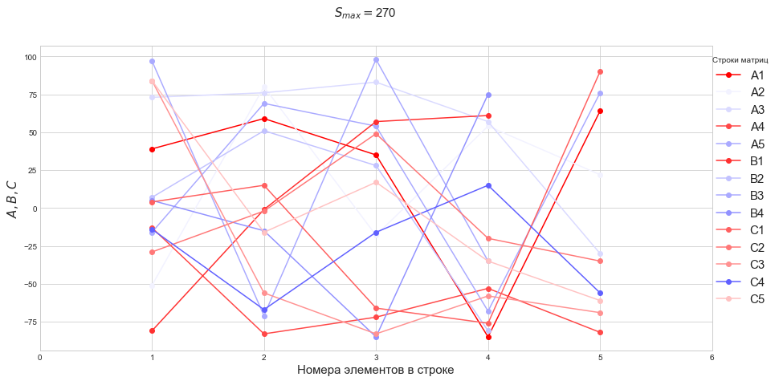

```python
pylab.figure(figsize=(15,7))
bwr = pylab.cm.get_cmap('bwr_r')

for i in range(3):
    for j in range(N[i]):
        pylab.plot(range(len(Y[i][j])), Y[i][j], '-o',
                   c=bwr((10*X[i][j]+2*i+j)/21),label=L[i]+str(j+1))

pylab.suptitle(r'$S_{max} = $' + str(max(S)), fontsize=15)
pylab.xlabel('Номера элементов в строке', fontsize=15)
pylab.ylabel(r'$A, B, C$', fontsize=15)
pylab.xticks(range(-1, max(N)+1), range(max(N)+2));
pylab.legend(title='Строки матриц', fontsize=15, shadow=True,
             bbox_to_anchor=(1.1,1.0));
```

```python
# Версия 2
print(20*' ' + 'Лаб.11\n' + 90*'=')

fin = str(input('Текстовый файл с элементами исходных матриц: '))
fout = str(input('Текстовый файл с элементами исходных матриц и результатами: '))

def read_txt(file_name):
    with open(file_name, 'r') as f:
        Y = f.readlines()
    NA = int(Y[0]); NB = int(Y[NA+1]); NC = int(Y[NA+NB+2])
    A = [x[1:-2].split() for x in Y[1:NA+1]]
    A = [[int(x) for x in A[i]] for i in range(NA)]
    B = [x[1:-2].split() for x in Y[NA+2:NA+NB+2]]
    B = [[int(x) for x in B[i]] for i in range(NB)]
    C = [x[1:-2].split() for x in Y[NA+NB+3:]]
    C = [[int(x) for x in C[i]] for i in range(NC)]
    N = [NA, NB, NC]; Y = [A, B, C]; L = ['A', 'B', 'C']
    return N, Y, L

def find_XSK(Y):
    X, S = 3 * [[0]], 3 * [0]
    for k in range(3):
        X[k] = [int(sum([int(Y[k][j][i] < Y[k][i][i]) \
               for j in range(len(Y[k][i]))]) == len(Y[k]) - 1) \
               for i in range(len(Y[k]))]
        S[k] = sum([sum(Y[k][i]) for i in range(len(Y[k]))])
    K = S.index(max(S))
    return X, S, K

def write_txt(file_name, N, Y, L, X, S, K):
    with open(file_name, 'w') as f:
        for i in range(3):
            f.write("{}\n".format(N[i]))
            for j in range(len(Y[i])):
                f.write("{}\n".format(Y[i][j]))
            f.write("{}\n".format(X[i]))
            f.write("{}\n".format(S[i]))
        f.write("{}\n".format(L[K]))

N, Y, L = read_txt(fin)
X, S, K = find_XSK(Y)

print(90*'=' + '\n')
for i in range(3):
    print('Матрица ', L[i], ': \n')
    for j in range(N[i]):
        print(Y[i][j])
    print('\n' + 'Массив X{}: \n'.format(L[i]))
    print(X[i])
    print('\n' + 'Сумма элементов S{}: {}\n'.format(L[i], S[i]))
    print(90*'=' + '\n')
print('\n' + 'Матрица с максимальной суммой элементов: {}\n'.format(L[K]))

write_txt(fout, N, Y, L, X, S, K)
```

```
                    Лаб.11
==========================================================================================
Текстовый файл с элементами исходных матриц: ABC_Lab11_5.txt
Текстовый файл с элементами исходных матриц и результатами: ABCXS_Lab11_5.txt
==========================================================================================

Матрица  A :

[-6, 1, -9]
[8, -9, 5]
[-3, -4, -7]

Массив XA:

[0, 0, 0]

Сумма элементов SA: -24

==========================================================================================

Матрица  B :

[-3, -7, -5, 4]
[-4, -7, -8, 0]
[-7, 9, -3, -1]
[-1, -4, -9, -4]

Массив XB:

[0, 0, 1, 0]

Сумма элементов SB: -50

==========================================================================================

Матрица  C :

[3, 2, -1]
[5, -7, 2]
[-2, -4, -6]

Массив XC:

[0, 0, 0]

Сумма элементов SC: -8

==========================================================================================


Матрица с максимальной суммой элементов: C
```

### 4. Таблица данных

| Класс | Имя | Описание (смысл, диапазон, точность) | Тип | Структура | Формат в/в |
| --- | --- | --- | --- | --- | --- |
| входные данные | fin | название текстового файла с элементами массива B | символ | строка | "+XX.txt" |
| входные данные | fout | название текстового файла с элементами массива B | символ | строка | "+XX.txt" |
| входные данные | A,B,C | вводимые из текстового файла исходные матрицы | цел | двумерные массивы | +XX (:5) |
| выходные данные | XA, XB, XC | выводимые в текстовый файл сформированные массивы | цел | одномерные массивы | +XX (:5) |
| выходные данные | SA, SB, SC | выводимые в текстовый файл суммы элементов матриц | цел | простые переменные | +XX (:5) |
| выходные данные | M | выводимое в текстовый файл обозначение матрицы с максимальной суммой элементов | символ | строка | "X" |
| промежуточные данные | i | индекс текущей строки, 1≤i≤50 | цел | простая переменная | --- |
| промежуточные данные | j | индекс текущего столбца, 1≤j≤50 | цел | простая переменная | --- |
| промежуточные данные | MAX1 | максимальный элемент в строке не на главной диагонали | цел | простая переменная | --- |
| промежуточные данные | MAX2 | элемент в строке на главной диагонали | цел | простая переменная | --- |

*! в Delphi выход из цикла с 1 до 20 с шагом +1 происходит при значении 21, из цикла с 20 до 1 – при 0*

### 5. Входная форма

- обр 1.1 Текстовый файл с элементами исходных матриц: $<fin>$
- обр 1.2 Текстовый файл с элементами исходных матриц и результатами: $<fout>$
- обр 2.1 Исходная матрица A: | Сформированный массив XA:
- обр 2.2 $ < A[11] > < A[12] > … < A[1n] > \\ ... \\ < A[n1] > < A[n2] > … < A[nn] >$
- обр 3.1 Исходная матрица B: | Сформированный массив XB:
- обр 3.2 $ < B[11] > < B[12] > … < B[1n] > \\ ... \\ < B[n1] > < B[n2] > … < B[nn] >$
- обр 4.1 Исходная матрица C: | Сформированный массив XC:
- обр 4.2 $ < C[11] > < C[12] > … < C[1n] > \\ ... \\ < C[n1] > < C[n2] > … < C[nn] >$

### 6. Выходная форма

- обр 5 Лаб. 11
- обр 6.1 Текстовый файл с элементами исходных матриц: $<fin>$
- обр 6.2 Текстовый файл с элементами исходных матриц и результатами: $<fout>$
- обр 7.1 Исходная матрица A: | Сформированный массив XA:
- обр 7.2 $ < A[11] > < A[12] > … < A[1n] > | <XA[1] \\ ... \\ < A[n1] > < A[n2] > … < A[nn] > | <XA[n]$
- обр 7.3 Сумма элементов матрицы A: $ < SA > $
- обр 8.1 Исходная матрица B: | Сформированный массив XB:
- обр 8.2 $ < B[11] > < B[12] > … < B[1n] > | <XB[1] \\ ... \\ < B[n1] > < B[n2] > … < B[nn] > | <XB[n]$
- обр 8.3 Сумма элементов матрицы B: $ < SB > $
- обр 9.1 Исходная матрица C: | Сформированный массив XC:
- обр 9.2 $ < C[11] > < C[12] > … < C[1n] > | <XC[1] \\ ... \\ < C[n1] > < C[n2] > … < C[nn] > | <XC[n]$
- обр 9.3 Сумма элементов матрицы C: $ < SC > $
- обр 10 Матрица с максимальной суммой элементов: $ < M > $

### 7. Аномалии

-

### 8. Функциональные тесты

[output not shown]

[output not shown]

| - | Результаты | № теста |
| --- | --- | --- |
| - | - | - |
| M | Максимальная вычислительная нагрузка = 52 (сравнение) + 66 (суммирование) + 2 (сравнение) | 1 |
| - | Соответствует ожидаемым числовым значениям | - |
| M | Максимальная вычислительная нагрузка = 24 (сравнение) + 41 (суммирование) + 2 (сравнение) | 2 |
| - | Соответствует ожидаемым числовым значениям и легко подтверждается визуально | - |
| M | Максимальная вычислительная нагрузка = 24 (сравнение) + 41 (суммирование) + 2 (сравнение) | 3 |
| - | Соответствует ожидаемым числовым значениям и легко подтверждается визуально | - |
| M | Максимальная вычислительная нагрузка = 24 (сравнение) + 41 (суммирование) + 2 (сравнение) | 4 |
| - | Соответствует ожидаемым числовым значениям и легко подтверждается визуально | - |
| M | Максимальная вычислительная нагрузка = 24 (сравнение) + 41 (суммирование) + 2 (сравнение) | 5 |
| - | Соответствует ожидаемым числовым значениям | - |

### 9. Метод

Отделим ввод-вывод от обработки данных и разделим задачу на три подзадачи:

1. *Подзадача А 0.1.* Запросить названия текстовых файлов ввода-вывода,

   считать из текстового файла ввода исходные данные (обр.1-4),

   затем вывести их на экран (обр.5-9) для визуального подтверждения и записать в файл.
2. *Подзадача А 0.2.* Решение поставленной задачи:

   *Версия 1*

   2.1. На основе введенных исходных данных (матриц $A, B, C$) с помощью процедур общего вида
   - сформировать массивы $XA, XB, XC$ по правилу $(*)$,
   - найти суммы элементов для каждой из заданных матриц $SA, SB, SC$,
   - определить матрицу $M$ с максимальной суммой элементов.

   *Версия 2*

   2.2. Выполнить перечисленные в пункте 2.1 действия с использованием хотя бы одной функции.
1. *Подзадача А 0.3.* Ввести полученные результаты ($XA, XB, XC, SA, SB, SC, M$)

   на экран (обр.7-10) и записать в файл вывода полученные результаты.

Ввод-вывод тривиален и представляет собой чисто техническую задачу.

Для осуществления процесса ввода-вывода и обработки матриц потребуются промежуточные переменные:

- `i` – индекс строки текущего элемента матрицы,
- `j` - индекс столбца текущего элемента матрицы,
- `MAX1` - максимальный элемент в строке не на главной диагонали,
- `MAX2` - элемент в строке на главной диагонали.

Их следует добавить в таблицу данных.

Алгоритм необходим только для обработка входных данных и расчета результата.

### 10. Алгоритм

[Sample diagrams](http://blockdiag.com/en/blockdiag/examples.html#sample-diagrams)

```python
%%file block_diagram

blockdiag {
    orientation = portrait;
    class start_end [shape = ellipse, fontsize = 15, color = lightskyblue];
    class input_out [shape = flowchart.input, fontsize = 15, width = 750, color = lightcyan];
    class main_box [shape = box, width = 500, height = 150, fontsize = 18];

    Начало ->
    "Вывод заголовка по обр.5 на экран" -> "Ввод имен файлов по обр.1.1,1.2" ->
    "Вывод имен файлов по обр.6.1,6.2 на экран" ->
    "Процедура 1. \nВвод исходных матриц А,B,C" ->
    "Процедура 2. \nФормирование массивов \nXA,XB,XC" ->
    "Процедура 3. \nПодсчет сумм SA,SB,SC" ->
    "Функция 1. \nОпределение матрицы M \nс максимальной суммой" ->
    "Процедура 4. \nВывод А,B,C,XA,XB,XC,SA,SB,SC,M \nна экран и в файл" ->
    Конец;

    Начало, Конец [class = "start_end"];
    "Вывод заголовка по обр.5 на экран" [class = "input_out"];
    "Ввод имен файлов по обр.1.1,1.2", "Вывод имен файлов по обр.6.1,6.2 на экран" [class = "input_out"];
    "Процедура 1. \nВвод исходных матриц А,B,C" [class = "main_box"];
    "Процедура 2. \nФормирование массивов \nXA,XB,XC" [class = "main_box"];
    "Процедура 3. \nПодсчет сумм SA,SB,SC" [class = "main_box"];
    "Функция 1. \nОпределение матрицы M \nс максимальной суммой"[class = "main_box"];
    "Процедура 4. \nВывод А,B,C,XA,XB,XC,SA,SB,SC,M \nна экран и в файл" [class = "main_box"];

    "Вывод имен файлов по обр.6.1,6.2 на экран" ->
    "Процедура 1. \nВвод исходных матриц А,B,C" [label = 'Вх. A,B,C', fontsize = 18];
    "Процедура 4. \nВывод А,B,C,XA,XB,XC,SA,SB,SC,M \nна экран и в файл" ->
    Конец [label = 'Вых. XA,XB,XC,SA,SB,SC,M', fontsize = 18];
}
```

```
Overwriting block_diagram
```

```python
!blockdiag block_diagram
```

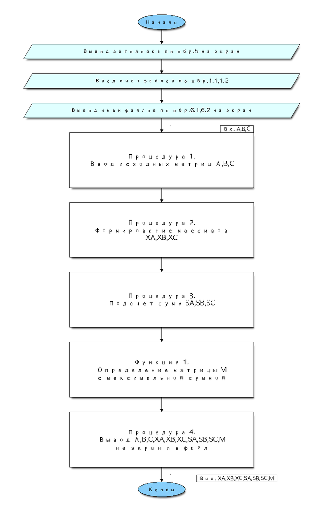

```python
Image("block_diagram.png")
```